# final4

Analysis of Used Car Price

Table of Contents

1. Data Collection
2. Data Processing
3. Exploratory Analysis & Data Visualization
4. Model: Analysis, Hypothesis Testing, & ML
5. Interpretation: Insight & Policy Decision

```python
import pandas as pd
import matplotlib.pyplot as plt
import seaborn as sns
```

Trying to see the car condition over the price for all other variables.

1. Data Collection

```python
filename = 'vehicles.csv'
df = pd.read_csv(filename)
df.head()
```

|  | id | url | region | region_url | price | year | manufacturer | model | condition | cylinders | ... | size | type | paint_color | image_url | description | county | state | lat | long | posting_date |
| --- | --- | --- | --- | --- | --- | --- | --- | --- | --- | --- | --- | --- | --- | --- | --- | --- | --- | --- | --- | --- | --- |
| 0 | 7222695916 | https://prescott.craigslist.org/cto/d/prescott... | prescott | https://prescott.craigslist.org | 6000 | NaN | NaN | NaN | NaN | NaN | ... | NaN | NaN | NaN | NaN | NaN | NaN | az | NaN | NaN | NaN |
| 1 | 7218891961 | https://fayar.craigslist.org/ctd/d/bentonville... | fayetteville | https://fayar.craigslist.org | 11900 | NaN | NaN | NaN | NaN | NaN | ... | NaN | NaN | NaN | NaN | NaN | NaN | ar | NaN | NaN | NaN |
| 2 | 7221797935 | https://keys.craigslist.org/cto/d/summerland-k... | florida keys | https://keys.craigslist.org | 21000 | NaN | NaN | NaN | NaN | NaN | ... | NaN | NaN | NaN | NaN | NaN | NaN | fl | NaN | NaN | NaN |
| 3 | 7222270760 | https://worcester.craigslist.org/cto/d/west-br... | worcester / central MA | https://worcester.craigslist.org | 1500 | NaN | NaN | NaN | NaN | NaN | ... | NaN | NaN | NaN | NaN | NaN | NaN | ma | NaN | NaN | NaN |
| 4 | 7210384030 | https://greensboro.craigslist.org/cto/d/trinit... | greensboro | https://greensboro.craigslist.org | 4900 | NaN | NaN | NaN | NaN | NaN | ... | NaN | NaN | NaN | NaN | NaN | NaN | nc | NaN | NaN | NaN |

5 rows × 26 columns

1. Data Processing

Trying to find more useful columns here...

As we can see above columns, we want to first drop some irrelevent columns before doing the actual data cleaning. As a result, let's start doing an analysis!

The goal for our data analysis is to see other factors that may affect the price. Then we can drop some columns consider no affects or little affects to the price flow, we choose: id, url, region_url, VIN, description, and image_url. These variables are not directly affect the car price as we know, then we will consider these variables will not affect the used car price here. To make sure that we still need the original data, we choose to save a copy here for the future analysis and keeping the original dataframe as the backup of the data to avoid re-run of reading the csv files.

```python
case=df.copy()
```

```python
#inplace=True indicates that we modify the original dataset
case.drop(columns=['id','url','region_url','VIN','description', 'image_url'],inplace=True)
case.head()
```

|  | region | price | year | manufacturer | model | condition | cylinders | fuel | odometer | title_status | transmission | drive | size | type | paint_color | county | state | lat | long | posting_date |
| --- | --- | --- | --- | --- | --- | --- | --- | --- | --- | --- | --- | --- | --- | --- | --- | --- | --- | --- | --- | --- |
| 0 | prescott | 6000 | NaN | NaN | NaN | NaN | NaN | NaN | NaN | NaN | NaN | NaN | NaN | NaN | NaN | NaN | az | NaN | NaN | NaN |
| 1 | fayetteville | 11900 | NaN | NaN | NaN | NaN | NaN | NaN | NaN | NaN | NaN | NaN | NaN | NaN | NaN | NaN | ar | NaN | NaN | NaN |
| 2 | florida keys | 21000 | NaN | NaN | NaN | NaN | NaN | NaN | NaN | NaN | NaN | NaN | NaN | NaN | NaN | NaN | fl | NaN | NaN | NaN |
| 3 | worcester / central MA | 1500 | NaN | NaN | NaN | NaN | NaN | NaN | NaN | NaN | NaN | NaN | NaN | NaN | NaN | NaN | ma | NaN | NaN | NaN |
| 4 | greensboro | 4900 | NaN | NaN | NaN | NaN | NaN | NaN | NaN | NaN | NaN | NaN | NaN | NaN | NaN | NaN | nc | NaN | NaN | NaN |

Then we will considering the missing values. The missing value of the dataset could affects the data trend heavily if the proportion of the missing values is large enough. To check the missing values with each columns, we have:

```python
#Checking the missing values to determine the ways of dealing the missing value
print(case.shape)
case.isna().sum()
```

```
(426880, 20)
```

```
region               0
price                0
year              1205
manufacturer     17646
model             5277
condition       174104
cylinders       177678
fuel              3013
odometer          4400
title_status      8242
transmission      2556
drive           130567
size            306361
type             92858
paint_color     130203
county          426880
state                0
lat               6549
long              6549
posting_date        68
dtype: int64
```

As we can see above with the remaining columns, we print out the value of the missing value of each column. Then we need to choose to drop specific column with certain amount of the missing value. As we notice, there's 426880 rows of data in total, then condition, cylinders, drive, size, paint_color, county, has over 100000 rows of missing data. However, I still want to do some analysis for these variables. Therefore, I will do a search of the missing value over 50% of the total rows. Then have the original copy of the dataframe to drop the columns with over 30% of the missing values and doing more accurate analysis of the other variables with the remaining columns, while doing the analysis with these variables to see the relation with used cars price.

```python
#Getting number of rows
row_num=len(case)
#Getting the columns with more than 50% of missing value
missing_columns = case.columns[case.isna().sum()>(row_num*0.5)]
print(missing_columns)
case.drop(columns=missing_columns, inplace=True)
#Save this with the less than 50% of the missing value
case2 = case.copy()
#Getting the columns with more than 30% of missing value
missing_columns = case.columns[case.isna().sum()>(row_num*0.3)]
print(missing_columns)

case.drop(columns=missing_columns, inplace=True)
case.head()
```

```
Index(['size', 'county'], dtype='object')
Index(['condition', 'cylinders', 'drive', 'paint_color'], dtype='object')
```

|  | region | price | year | manufacturer | model | fuel | odometer | title_status | transmission | type | state | lat | long | posting_date |
| --- | --- | --- | --- | --- | --- | --- | --- | --- | --- | --- | --- | --- | --- | --- |
| 0 | prescott | 6000 | NaN | NaN | NaN | NaN | NaN | NaN | NaN | NaN | az | NaN | NaN | NaN |
| 1 | fayetteville | 11900 | NaN | NaN | NaN | NaN | NaN | NaN | NaN | NaN | ar | NaN | NaN | NaN |
| 2 | florida keys | 21000 | NaN | NaN | NaN | NaN | NaN | NaN | NaN | NaN | fl | NaN | NaN | NaN |
| 3 | worcester / central MA | 1500 | NaN | NaN | NaN | NaN | NaN | NaN | NaN | NaN | ma | NaN | NaN | NaN |
| 4 | greensboro | 4900 | NaN | NaN | NaN | NaN | NaN | NaN | NaN | NaN | nc | NaN | NaN | NaN |

```python
missing_columns = missing_columns.to_numpy()
print(missing_columns)
case2.head()
```

```
['condition' 'cylinders' 'drive' 'paint_color']
```

|  | region | price | year | manufacturer | model | condition | cylinders | fuel | odometer | title_status | transmission | drive | type | paint_color | state | lat | long | posting_date |
| --- | --- | --- | --- | --- | --- | --- | --- | --- | --- | --- | --- | --- | --- | --- | --- | --- | --- | --- |
| 0 | prescott | 6000 | NaN | NaN | NaN | NaN | NaN | NaN | NaN | NaN | NaN | NaN | NaN | NaN | az | NaN | NaN | NaN |
| 1 | fayetteville | 11900 | NaN | NaN | NaN | NaN | NaN | NaN | NaN | NaN | NaN | NaN | NaN | NaN | ar | NaN | NaN | NaN |
| 2 | florida keys | 21000 | NaN | NaN | NaN | NaN | NaN | NaN | NaN | NaN | NaN | NaN | NaN | NaN | fl | NaN | NaN | NaN |
| 3 | worcester / central MA | 1500 | NaN | NaN | NaN | NaN | NaN | NaN | NaN | NaN | NaN | NaN | NaN | NaN | ma | NaN | NaN | NaN |
| 4 | greensboro | 4900 | NaN | NaN | NaN | NaN | NaN | NaN | NaN | NaN | NaN | NaN | NaN | NaN | nc | NaN | NaN | NaN |

As we can see here, I save the case2 with the variables that's keeping less than or equal to 50% of the missing value, and case with less than or equal to 30% of the missing values. After dropping these valeus, I will have more values keep with case and less values to keep with case2 becasue case2 need to drop more rows than the case.

```python
case.dropna(inplace=True)
case2.dropna(inplace=True)
print('30% missing value:\n', case.head())
print('30% wtih', len(case), 'rows')
print('50% missing value\n:', case2.head())
print('50% with', len(case2), 'rows')
```

```
30% missing value:
     region  price    year manufacturer                     model fuel  \
27  auburn  33590  2014.0          gmc  sierra 1500 crew cab slt  gas
28  auburn  22590  2010.0    chevrolet            silverado 1500  gas
29  auburn  39590  2020.0    chevrolet       silverado 1500 crew  gas
30  auburn  30990  2017.0       toyota      tundra double cab sr  gas
31  auburn  15000  2013.0         ford                 f-150 xlt  gas

    odometer title_status transmission    type state     lat     long  \
27   57923.0        clean        other  pickup    al  32.590 -85.4800
28   71229.0        clean        other  pickup    al  32.590 -85.4800
29   19160.0        clean        other  pickup    al  32.590 -85.4800
30   41124.0        clean        other  pickup    al  32.590 -85.4800
31  128000.0        clean    automatic   truck    al  32.592 -85.5189

                posting_date
27  2021-05-04T12:31:18-0500
28  2021-05-04T12:31:08-0500
29  2021-05-04T12:31:25-0500
30  2021-05-04T10:41:31-0500
31  2021-05-03T14:02:03-0500
30% wtih 301094 rows
50% missing value
:     region  price    year manufacturer                        model  \
31  auburn  15000  2013.0         ford                    f-150 xlt
32  auburn  27990  2012.0          gmc  sierra 2500 hd extended cab
33  auburn  34590  2016.0    chevrolet        silverado 1500 double
34  auburn  35000  2019.0       toyota                       tacoma
35  auburn  29990  2016.0    chevrolet        colorado extended cab

    condition    cylinders fuel  odometer title_status transmission drive  \
31  excellent  6 cylinders  gas  128000.0        clean    automatic   rwd
32       good  8 cylinders  gas   68696.0        clean        other   4wd
33       good  6 cylinders  gas   29499.0        clean        other   4wd
34  excellent  6 cylinders  gas   43000.0        clean    automatic   4wd
35       good  6 cylinders  gas   17302.0        clean        other   4wd

      type paint_color state      lat       long              posting_date
31   truck       black    al  32.5920 -85.518900  2021-05-03T14:02:03-0500
32  pickup       black    al  32.5900 -85.480000  2021-05-03T13:41:25-0500
33  pickup      silver    al  32.5900 -85.480000  2021-05-03T12:41:33-0500
34   truck        grey    al  32.6013 -85.443974  2021-05-03T12:12:59-0500
35  pickup         red    al  32.5900 -85.480000  2021-05-03T11:31:14-0500
50% with 115435 rows
```

As considering the value of the used car, we found an obvious problem with the year relates to the price. In reality, when we are considering buying a car, we will consider the car_age instead of only the year that it made. To make sure this factor is considered, we make a new column call car_age to represent the car age ehrn the car sale.

```python
case['posting_date'] = pd.to_datetime(case['posting_date'], format='%Y-%m-%dT%H:%M:%S%z', utc=True)
case2['posting_date'] = pd.to_datetime(case2['posting_date'], format='%Y-%m-%dT%H:%M:%S%z', utc=True)

case['posting_year'] = case['posting_date'].dt.year
case2['posting_year'] = case2['posting_date'].dt.year

case['car_age'] = case['posting_year'] - case['year']
case2['car_age'] = case2['posting_year'] - case2['year']
case=case.reset_index(drop=True)
case2=case2.reset_index(drop=True)
```

1. Exploratory Analysis & Data Visualization

Now that we have different datasets, we can start thinking about how the price vary between the two datast that we got right now. First, we will plot two graphs of the price over the car_age for each dataset. To make sure that we didn't need to reload the dataset again from beginning, we will doing the dataframe copy again here.

```python
temp30 = case.copy()
temp50 = case2.copy()
temp50.head()
```

|  | region | price | year | manufacturer | model | condition | cylinders | fuel | odometer | title_status | transmission | drive | type | paint_color | state | lat | long | posting_date | posting_year | car_age |
| --- | --- | --- | --- | --- | --- | --- | --- | --- | --- | --- | --- | --- | --- | --- | --- | --- | --- | --- | --- | --- |
| 0 | auburn | 15000 | 2013.0 | ford | f-150 xlt | excellent | 6 cylinders | gas | 128000.0 | clean | automatic | rwd | truck | black | al | 32.5920 | -85.518900 | 2021-05-03 19:02:03+00:00 | 2021 | 8.0 |
| 1 | auburn | 27990 | 2012.0 | gmc | sierra 2500 hd extended cab | good | 8 cylinders | gas | 68696.0 | clean | other | 4wd | pickup | black | al | 32.5900 | -85.480000 | 2021-05-03 18:41:25+00:00 | 2021 | 9.0 |
| 2 | auburn | 34590 | 2016.0 | chevrolet | silverado 1500 double | good | 6 cylinders | gas | 29499.0 | clean | other | 4wd | pickup | silver | al | 32.5900 | -85.480000 | 2021-05-03 17:41:33+00:00 | 2021 | 5.0 |
| 3 | auburn | 35000 | 2019.0 | toyota | tacoma | excellent | 6 cylinders | gas | 43000.0 | clean | automatic | 4wd | truck | grey | al | 32.6013 | -85.443974 | 2021-05-03 17:12:59+00:00 | 2021 | 2.0 |
| 4 | auburn | 29990 | 2016.0 | chevrolet | colorado extended cab | good | 6 cylinders | gas | 17302.0 | clean | other | 4wd | pickup | red | al | 32.5900 | -85.480000 | 2021-05-03 16:31:14+00:00 | 2021 | 5.0 |

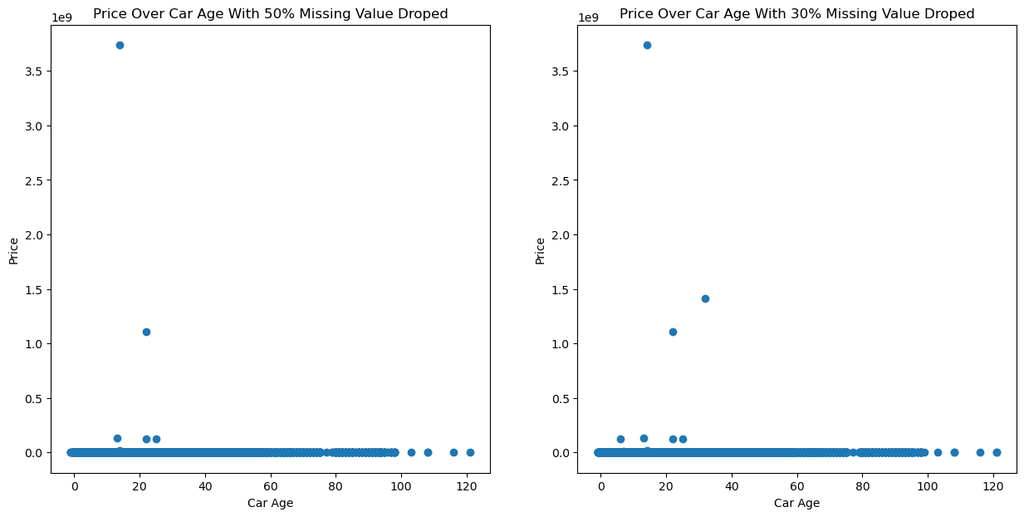

```python
fig, axs = plt.subplots(1,2, figsize=(15,7))
axs[0].scatter(temp50['car_age'], temp50['price'])
axs[0].set_title('Price Over Car Age With 50% Missing Value Droped')
axs[0].set_xlabel('Car Age')
axs[0].set_ylabel('Price')

axs[1].scatter(temp30['car_age'], temp30['price'])
axs[1].set_title('Price Over Car Age With 30% Missing Value Droped')
axs[1].set_xlabel('Car Age')
axs[1].set_ylabel('Price')
plt.show()
```

With the current plot, we can find another issue that happen here, after the basic data cleanning, we still have some outlier of the car price that is being too large for the dataset and showing no trends for the plots, then what we doing here is to clean the data again to make sure the plotting is correct.

```python
print("50% Missing Value" )
print(temp50['price'].describe())
print("30% Missing Value")
print(temp30['price'].describe())
```

```
50% Missing Value
count    1.154350e+05
mean     6.088899e+04
std      1.149310e+07
min      0.000000e+00
25%      5.700000e+03
50%      1.099500e+04
75%      2.290000e+04
max      3.736929e+09
Name: price, dtype: float64
30% Missing Value
count    3.010940e+05
mean     4.100652e+04
std      7.569418e+06
min      0.000000e+00
25%      6.900000e+03
50%      1.559000e+04
75%      2.797950e+04
max      3.736929e+09
Name: price, dtype: float64
```

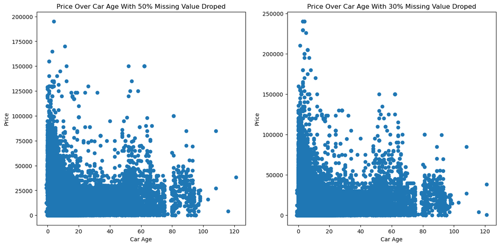

```python
outlier = temp50[temp50['price']>250000]
temp50.drop(outlier.index, inplace=True)
outlier = temp30[temp30['price']>250000]
temp30.drop(outlier.index, inplace=True)
fig, axs = plt.subplots(1,2, figsize=(15,7))
axs[0].scatter(temp50['car_age'], temp50['price'])
axs[0].set_title('Price Over Car Age With 50% Missing Value Droped')
axs[0].set_xlabel('Car Age')
axs[0].set_ylabel('Price')

axs[1].scatter(temp30['car_age'], temp30['price'])
axs[1].set_title('Price Over Car Age With 30% Missing Value Droped')
axs[1].set_xlabel('Car Age')
axs[1].set_ylabel('Price')
plt.show()
```